# SNCF Trains analysis

```r
options(warn=-1)
df_raw = read.csv("full_trains.csv")
library(igraph)
library(ggraph)
library(tidyverse)
library(scales)
library(patchwork)
library(dplyr)
library(viridis)
library(hrbrthemes)
```

Select everything except comments for cancellation, departure and arrival delays Calculate the % of late departures Calculate the mean monthly % cancelled

```r
df = df_raw %>%
  select(-c(comment_cancellations,comment_delays_at_departure,comment_delays_on_arrival))

df = df %>%
  mutate(pct_late_departure = num_late_at_departure/total_num_trips,
         mean_monthly_pct_cancelled = num_of_canceled_trains/total_num_trips)
```

```r
head(df)
```

|  | year | month | service | departure_station | arrival_station | journey_time_avg | total_num_trips | num_of_canceled_trains | num_late_at_departure | avg_delay_late_at_departure | avg_delay_all_departing | num_arriving_late | avg_delay_late_on_arrival | avg_delay_all_arriving | delay_cause_external_cause | delay_cause_rail_infrastructure | delay_cause_traffic_management | delay_cause_rolling_stock | delay_cause_station_management | delay_cause_travelers | num_greater_15_min_late | avg_delay_late_greater_15_min | num_greater_30_min_late | num_greater_60_min_late | pct_late_departure | mean_monthly_pct_cancelled |
| --- | --- | --- | --- | --- | --- | --- | --- | --- | --- | --- | --- | --- | --- | --- | --- | --- | --- | --- | --- | --- | --- | --- | --- | --- | --- | --- |
| 1 | 2017 | 9 | National | PARIS EST | METZ | 85.13378 | 299 | 0 | 15 | 11.55000 | 0.7520067 | 17 | 13.79412 | 0.4198439 | 0.2500000 | 0.0000000 | 0.16666667 | 0.4166667 | 0.16666667 | 0.00000000 | 6 | 24.03333 | 1 | 0 | 0.05016722 | 0.000000000 |
| 2 | 2017 | 9 | National | REIMS | PARIS EST | 47.06452 | 218 | 1 | 10 | 14.65333 | 1.2635177 | 23 | 13.57029 | 1.1375576 | 0.2500000 | 0.3750000 | 0.12500000 | 0.1250000 | 0.06250000 | 0.06250000 | 9 | 21.49815 | 1 | 0 | 0.04587156 | 0.004587156 |
| 3 | 2017 | 9 | National | PARIS EST | STRASBOURG | 116.23494 | 333 | 1 | 20 | 13.69417 | 1.1392570 | 19 | 21.53246 | 1.5863956 | 0.2142857 | 0.2142857 | 0.07142857 | 0.2857143 | 0.21428571 | 0.00000000 | 14 | 24.69405 | 3 | 0 | 0.06006006 | 0.003003003 |
| 4 | 2017 | 9 | National | PARIS LYON | AVIGNON TGV | 161.08958 | 481 | 1 | 36 | 20.98843 | 1.4062153 | 61 | 26.56667 | 4.7885417 | 0.1551724 | 0.1206897 | 0.31034483 | 0.3448276 | 0.03448276 | 0.03448276 | 40 | 34.04750 | 21 | 5 | 0.07484407 | 0.002079002 |
| 5 | 2017 | 9 | National | PARIS LYON | BELLEGARDE (AIN) | 164.45263 | 190 | 0 | 16 | 20.96354 | 1.7289474 | 38 | 23.15175 | 6.0088596 | 0.1666667 | 0.2500000 | 0.25000000 | 0.3055556 | 0.00000000 | 0.02777778 | 26 | 28.40128 | 8 | 1 | 0.08421053 | 0.000000000 |
| 6 | 2017 | 9 | National | PARIS LYON | BESANCON FRANCHE COMTE TGV | 128.52105 | 191 | 1 | 18 | 19.96389 | 1.8387719 | 18 | 31.58796 | 5.0336842 | 0.1111111 | 0.1111111 | 0.22222222 | 0.5000000 | 0.00000000 | 0.05555556 | 15 | 35.79667 | 8 | 1 | 0.09424084 | 0.005235602 |

Check for missing values

```r
na_count = data.frame(na_sum = colSums(is.na(df)))%>%
arrange(desc(na_sum))

na_count %>%
filter(na_sum !=0)
```

|  | na_sum |
| --- | --- |
| service | 1430 |
| delay_cause_external_cause | 170 |
| delay_cause_rail_infrastructure | 170 |
| delay_cause_traffic_management | 170 |
| delay_cause_rolling_stock | 170 |
| delay_cause_station_management | 170 |
| delay_cause_travelers | 170 |
| num_arriving_late | 9 |
| avg_delay_late_on_arrival | 9 |
| num_greater_15_min_late | 5 |

[output cut: 3 more lines]

Check the service variable

```r
df %>%
group_by(year,service) %>%
count()
```

| year | service | n |
| --- | --- | --- |
| 2015 | International | 144 |
| 2015 | National | 1200 |
| 2016 | International | 144 |
| 2016 | National | 1200 |
| 2017 | International | 144 |
| 2017 | National | 1200 |
| 2018 | NA | 1430 |

No service info for 2018. We can use the ggraph package to plot the stations network.

```
Using "stress" as default layout
```

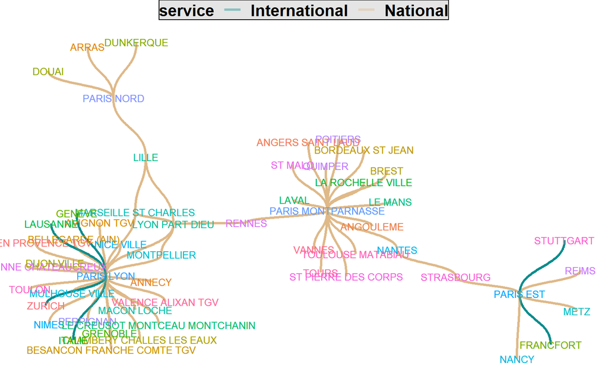

```r
p1 =  df %>%
  filter(year != 2018) %>%
  group_by(departure_station,arrival_station,service) %>%
  mutate(id = map2_chr(departure_station, arrival_station,
                       ~str_flatten(sort(c(.x,.y)))))%>%     # For each unique pairs of stations create an id
  group_by(id) %>%
  rename(from = departure_station,to = arrival_station)


p1 = p1[,c("from","to","service","id")]
graph1 = graph.data.frame(p1)



   ggraph(graph1) +
    geom_node_text(aes(label = name,color = name),size = 3)+
  geom_edge_diagonal(aes(color = service),alpha = 0.4,width = 1)+
  scale_edge_color_manual(values=c("darkcyan","burlywood"))+
  geom_node_text(aes(label = name,color = name),size = 3)+
    theme_void()+

    scale_colour_discrete(name  ="service",
                            breaks=c("National", "International"),
                            labels=c("National", "International"))+
    theme(legend.position="top",
          legend.background = element_rect(fill="gray90"),
        legend.text =element_text(size=14,face="bold"),
        legend.title = element_text(size=14,face="bold"))
```

There are 6 international destinations: Italy,Frankfurt,Stuttgart,Lausanne,Zurich,Geneva. The two central stations are PARIS LYON and PARIS MONTPARNASSE.

Now, let’s look at the rate of delays by year for each month.

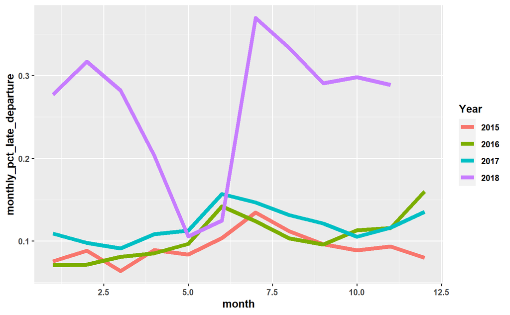

```r
df %>%
  mutate(pct_late_departure = num_late_at_departure/total_num_trips) %>%
  group_by(year,month) %>%
  summarise(monthly_pct_late_departure = mean(pct_late_departure)) %>%
  ggplot(aes(month,monthly_pct_late_departure,color = factor(year)))+
    geom_line(size = 2)+
    labs(color = "Year")+
theme(axis.text=element_text(face="bold"),
        axis.title=element_text(face="bold"),
        legend.text =element_text(face="bold"),
        legend.title = element_text(face="bold"))
```

2018 was nuts. After looking it up in google I found that during 2018 SNCF went on strike due to planned government reforms. https://www.cnbc.com/2018/04/03/france-train-strike-scnf-action-brings-travel-chaos.html

We can also learn by looking at the plot that the peak of delays occurs around June. Tourism maybe?

But that’s quite a messy graph because we need to recode our year variable

```r
Sys.setlocale("LC_TIME", "C")
```

```
[1] "C"
```

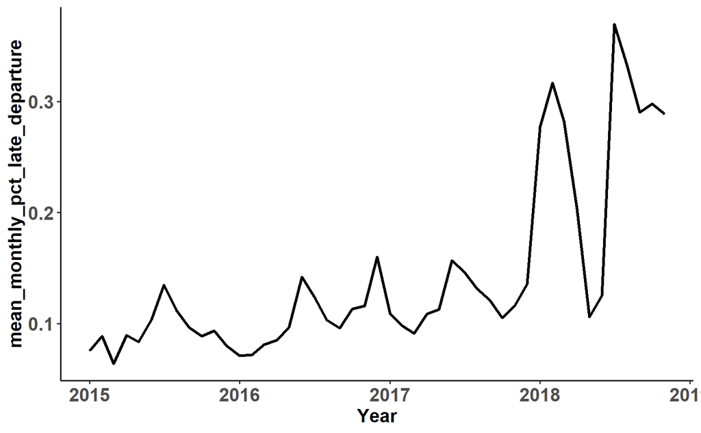

```r
df = df %>% mutate(date = as.Date(sprintf("%d-%02d-01",year,month)))

df %>%
  group_by(date) %>%
  summarise(mean_monthly_pct_late_departure = mean(pct_late_departure)) %>%
  ggplot(aes(date,mean_monthly_pct_late_departure,size = 1))+
  theme_classic()+
  xlab("Year")+
  geom_line(size = 1)+
theme(axis.text=element_text(size=14,face="bold"),
        axis.title=element_text(size=14,face="bold"),
        legend.text =element_text(size=14,face="bold"),
        legend.title = element_text(size=14,face="bold"))
```

Let’s compare cancellations and delays

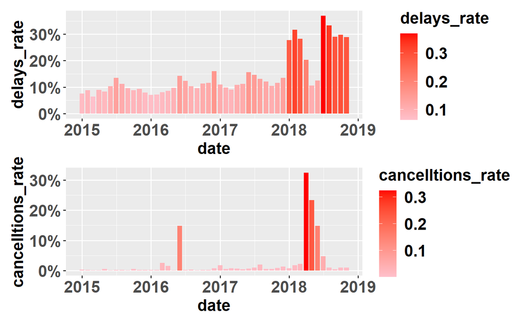

```r
p3 = df %>%
  group_by(year,date) %>%
  summarise(delays_rate = mean(pct_late_departure)) %>%
  ungroup() %>%
  ggplot(aes(date,delays_rate,fill=delays_rate))+
  scale_fill_gradient(low="pink", high="red")+
  scale_y_continuous(labels = percent_format())+
  geom_bar(stat = "identity")+
theme(axis.text=element_text(size=16,face="bold"),
        axis.title=element_text(size=16,face="bold"),
        legend.text =element_text(size=16,face="bold"),
        legend.title = element_text(size=16,face="bold"))
p4 = df %>%
  group_by(year,date) %>%
  summarise(cancelltions_rate = mean(mean_monthly_pct_cancelled)) %>%
  ggplot(aes(date,cancelltions_rate,fill=cancelltions_rate))+
  scale_fill_gradient(low="pink", high="red")+
  scale_y_continuous(labels = percent_format())+
  geom_bar(stat = "identity")+
theme(axis.text=element_text(size=16,face="bold"),
        axis.title=element_text(size=16,face="bold"),
        legend.text =element_text(size=16,face="bold"),
        legend.title = element_text(size=16,face="bold"))
p3/p4
```

So when the rate of delays went down cancellations went up in 2018 Do busy stations (=more circulating trains) tend to have delays more often than not?

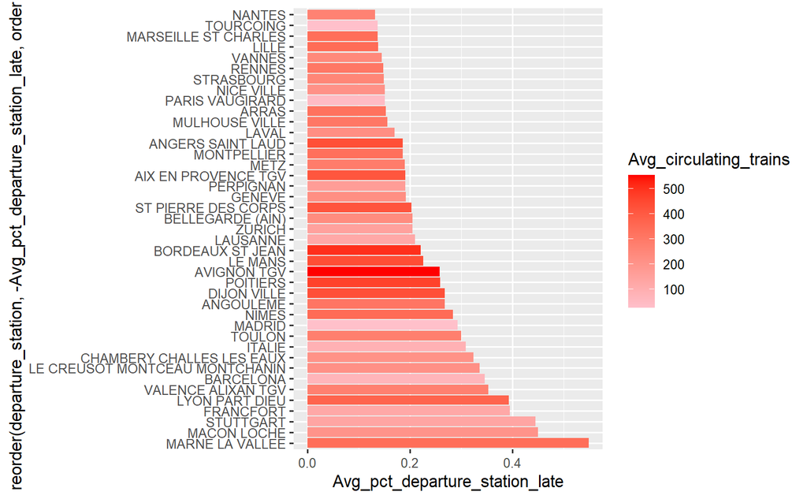

```r
df %>%
  group_by(departure_station) %>%
  summarise(Avg_pct_departure_station_late = mean(pct_late_departure),
            Avg_circulating_trains = mean(total_num_trips)) %>%
  arrange(desc(Avg_pct_departure_station_late)) %>%
  filter(Avg_pct_departure_station_late>0.1) %>%
  ggplot(aes(x = reorder(departure_station, -Avg_pct_departure_station_late,order = F), y= Avg_pct_departure_station_late,fill= Avg_circulating_trains))+
  scale_fill_gradient(low='pink', high='red')+
  geom_bar(stat = "identity")+
  coord_flip()
```

How do the causes of delay fluctuate over time?

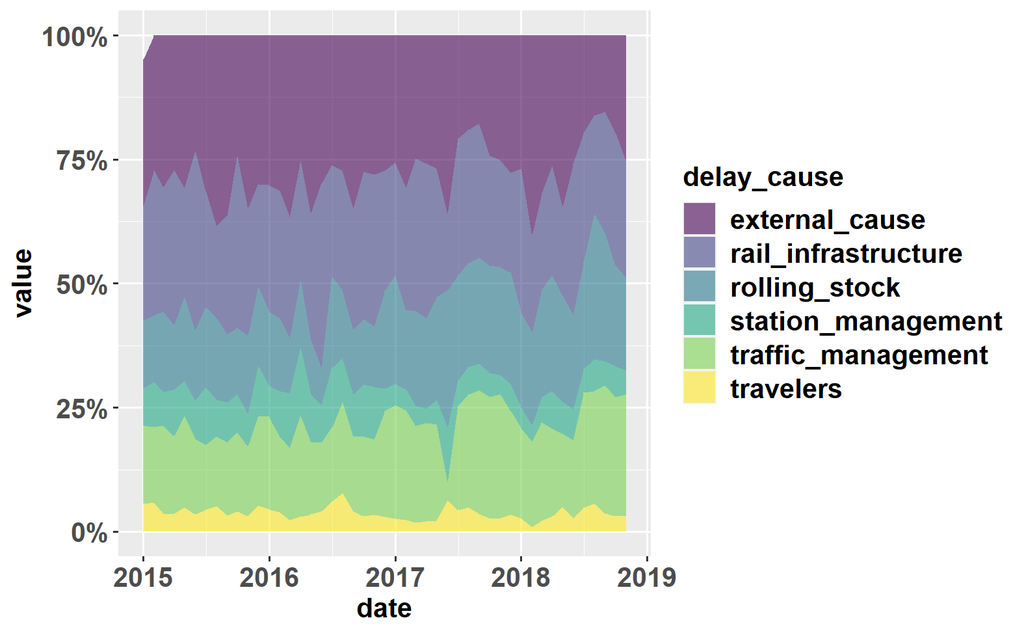

```r
df %>%
  group_by(year,month) %>%
        summarise(across(starts_with("delay_"), mean,na.rm = T)) %>%
         mutate(date = as.Date(sprintf("%d-%02d-01",year,month))) %>%
        pivot_longer(cols = starts_with("delay"),names_to = "delay") %>%
        mutate(delay = substring(delay,nchar("delay_cause_")+1)) %>%
        rename(delay_cause = delay) %>%
  ggplot(aes(date,value,fill = delay_cause))+
  scale_fill_viridis(discrete = T)+
  geom_area(alpha = 0.6)+
  scale_y_continuous(labels = percent_format())+
theme(axis.text=element_text(size=14,face="bold"),
        axis.title=element_text(size=14,face="bold"),
        legend.text =element_text(size=14,face="bold"),
        legend.title = element_text(size=14,face="bold"))
```

Group by service

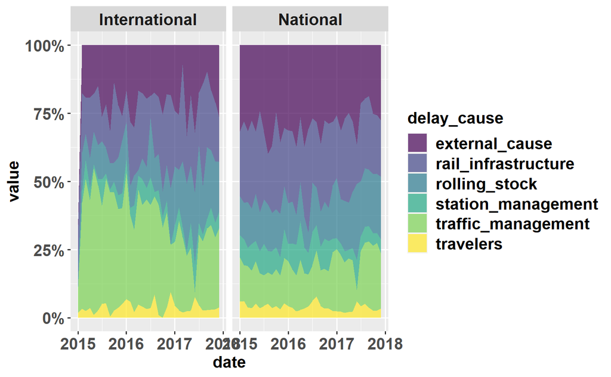

```r
df %>%
  filter(year != 2018) %>%
  group_by(year,month,service) %>%
        summarise(across(starts_with("delay_"), mean,na.rm = T)) %>%
         mutate(date = as.Date(sprintf("%d-%02d-01",year,month))) %>%
        pivot_longer(cols = starts_with("delay"),names_to = "delay") %>%
        mutate(delay = substring(delay,nchar("delay_cause_")+1)) %>%
        rename(delay_cause = delay) %>%
  ggplot(aes(date,value,fill = delay_cause))+
  scale_fill_viridis(discrete = T)+
  facet_grid(~service) +
  geom_area(alpha = 0.7)+
  scale_y_continuous(labels = percent_format())+
theme(axis.text=element_text(size=14,face="bold"),
        axis.title=element_text(size=14,face="bold"),
        legend.text =element_text(size=14,face="bold"),
        legend.title = element_text(size=14,face="bold"),
     strip.text = element_text(face="bold", size=14))
```